# Publication bias and outlier analyses

2024-06-06

**Load packages and dataset**

```r
knitr::opts_chunk$set(
    message = FALSE,
    warning = FALSE,
    include = TRUE,
    error = FALSE,
    fig.width=8,
    fig.height=6
)
windowsFonts(Times = windowsFont("Times New Roman"))
options(scipen = 999, digits = 2)


library(groundhog)
groundhog.library(c("tidyverse", "metafor", "meta"), date = "2024-02-14")
groundhog.library("github::MathiasHarrer/dmetar", date = "2024-02-14")
```

# 1 Meta-analysis 1

```r
MA1 <- readRDS("data/preprocessed/MA_all.rds") %>%
  filter(id_ma == 1)
```

## 1.1 Publication bias analysis

The analysis in this section mostly follows the tutorial [here](https://bookdown.org/MathiasHarrer/Doing_Meta_Analysis_in_R/pub-bias.html#addressing-pubbias).

### 1.1.1 PET-PEESE

Collate the necessary variables For the PET-PEESE model, the effect sizes (here SMDs), their SEs, their variances, and their inverse-variance weights, are needed.

```r
petpeese <- data.frame(smd = MA1$smd_ma) # smds
petpeese$v <- MA1$v_ma # sampling variances (extracted from the figures)
petpeese$se <- MA1$se_ma # standard errors of SMD estimates
petpeese$w <- 1/petpeese$v # inverse variance weights
```

PET (precision-effect test)

```r
pet <- lm(smd ~ se, weights = w, data = petpeese)
summary(pet)$coefficients
```

```
##             Estimate Std. Error t value Pr(>|t|)
## (Intercept)     0.34       0.29    1.17     0.26
## se              0.67       0.76    0.89     0.39
```

PEESE (precision-effect estimate with standard error)

```r
peese <- lm(smd ~ v, weights = w, data = petpeese)
summary(peese)$coefficients
```

```
##             Estimate Std. Error t value Pr(>|t|)
## (Intercept)     0.44       0.17    2.68    0.015
```

### 1.1.2 P-Curve

P-Curve

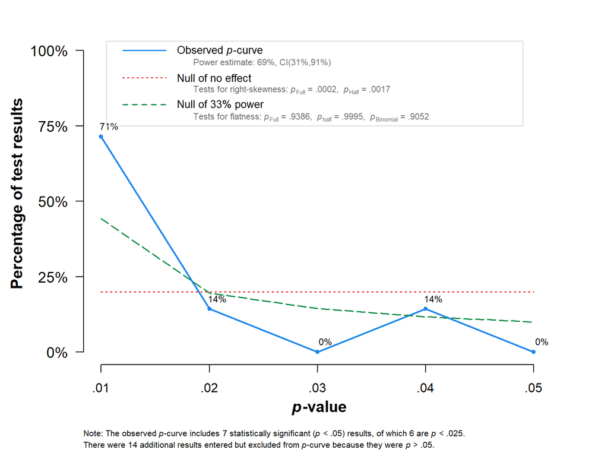

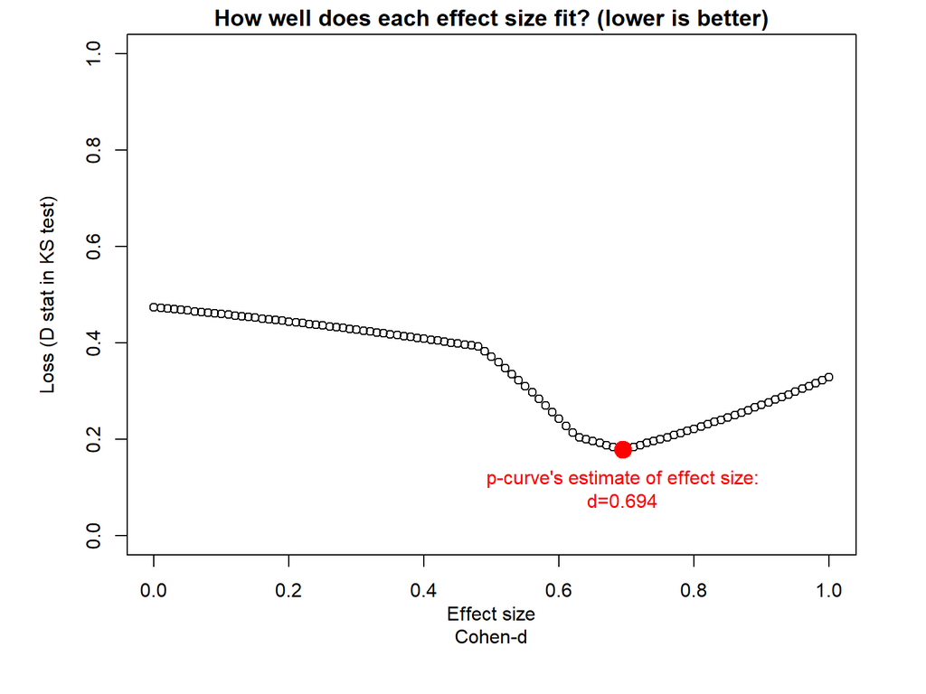

```
## P-curve analysis
##  -----------------------
## - Total number of provided studies: k = 21
## - Total number of p<0.05 studies included into the analysis: k = 7 (33.33%)
## - Total number of studies with p<0.025: k = 6 (28.57%)
##
## Results
##  -----------------------
##                     pBinomial zFull pFull zHalf pHalf
## Right-skewness test     0.062  -3.6  0.00  -2.9 0.002
## Flatness test           0.905   1.5  0.94   3.3 1.000
## Note: p-values of 0 or 1 correspond to p<0.001 and p>0.999, respectively.
## Power Estimate: 69% (31%-91%)
##
## Evidential value
##  -----------------------
## - Evidential value present: yes
## - Evidential value absent/inadequate: no
##
## P-curve's estimate of the true effect size: d=0.69
```

```r
ma3 <- metagen(TE = smd_ma,
              seTE = se_ma,
              studlab = as.character(id_comparison),
              data = MA1,
              sm = "SMD",
              fixed = FALSE,
              random = TRUE, # a random effects MA.
              method.tau = "DL", # DerSimonian-Laird estimator
                 )

pcurve(ma3,
       effect.estimation = TRUE,
       N = MA1$nt_ma + MA1$nc_ma,
       dmin = 0,
       dmax = 1)
```

No indication of bias.

### 1.1.3 Three-parameter selection model

Create a `metafor` package meta-analysis object, necessary for the `selmodel` function

```r
ma3_metafor <- rma(yi = smd_ma,
          sei = se_ma,
          data = MA1,
          method = "DL")
```

Fit the selection model

```r
selmodel(ma3_metafor,
         type = "stepfun",
         steps = 0.025)
```

```
##
## Random-Effects Model (k = 21; tau^2 estimator: ML)
##
## tau^2 (estimated amount of total heterogeneity): 0.0485 (SE = 0.0567)
## tau (square root of estimated tau^2 value):      0.2202
##
## Test for Heterogeneity:
## LRT(df = 1) = 1.3287, p-val = 0.2490
##
## Model Results:
##
## estimate      se    zval    pval   ci.lb   ci.ub
##   0.5884  0.1551  3.7936  0.0001  0.2844  0.8925  ***
##
## Test for Selection Model Parameters:
## LRT(df = 1) = 0.0007, p-val = 0.9784
##
## Selection Model Results:
##
##                      k  estimate      se     zval    pval   ci.lb   ci.ub
## 0     < p <= 0.025   7    1.0000     ---      ---     ---     ---     ---
## 0.025 < p <= 1      14    0.9796  0.7453  -0.0273  0.9782  0.0000  2.4405
##
## ---
## Signif. codes:  0 '***' 0.001 '**' 0.01 '*' 0.05 '.' 0.1 ' ' 1
```

No indication of bias.

## 1.2 Outlier/influence diagnostics

### 1.2.1 Leave-one-out analysis

```r
metainf(ma3, pooled = "random")
```

```
## Influential analysis (random effects model)
##
##                    SMD           95%-CI  p-value   tau^2     tau    I^2
## Omitting 1      0.6053 [0.4046; 0.8061] < 0.0001  0.0499  0.2234  25.5%
## Omitting 2      0.6182 [0.4170; 0.8195] < 0.0001  0.0450  0.2122  22.9%
## Omitting 3      0.6024 [0.3985; 0.8063] < 0.0001  0.0534  0.2312  26.6%
## Omitting 4      0.6045 [0.4048; 0.8042] < 0.0001  0.0491  0.2216  25.3%
## Omitting 5      0.6016 [0.3975; 0.8058] < 0.0001  0.0538  0.2319  26.7%
## Omitting 6      0.6394 [0.4509; 0.8279] < 0.0001  0.0217  0.1474  12.1%
## Omitting 7      0.6384 [0.4484; 0.8285] < 0.0001  0.0238  0.1543  13.1%
## Omitting 8      0.5432 [0.3664; 0.7201] < 0.0001  0.0131  0.1145   8.2%
## Omitting 9      0.5676 [0.3689; 0.7664] < 0.0001  0.0441  0.2099  22.9%
## Omitting 10     0.5798 [0.3798; 0.7799] < 0.0001  0.0495  0.2225  25.5%
## Omitting 11     0.5730 [0.3779; 0.7682] < 0.0001  0.0422  0.2054  22.6%
## Omitting 12     0.5825 [0.3810; 0.7840] < 0.0001  0.0515  0.2270  26.2%
## Omitting 13     0.5712 [0.3634; 0.7789] < 0.0001  0.0517  0.2274  24.7%
## Omitting 14     0.6051 [0.4020; 0.8082] < 0.0001  0.0520  0.2281  26.1%
## Omitting 15     0.5923 [0.3886; 0.7960] < 0.0001  0.0547  0.2340  27.3%
## Omitting 16     0.5686 [0.3754; 0.7618] < 0.0001  0.0386  0.1965  21.0%
## Omitting 17     0.5603 [0.3580; 0.7627] < 0.0001  0.0439  0.2095  22.0%
## Omitting 18     0.6032 [0.4015; 0.8050] < 0.0001  0.0516  0.2271  26.2%
## Omitting 19     0.5906 [0.3858; 0.7953] < 0.0001  0.0551  0.2347  27.2%
## Omitting 20     0.5792 [0.3657; 0.7926] < 0.0001  0.0579  0.2407  25.9%
## Omitting 21     0.5953 [0.3908; 0.7999] < 0.0001  0.0550  0.2346  27.3%
##
## Pooled estimate 0.5909 [0.3957; 0.7862] < 0.0001  0.0458  0.2139  23.5%
##
## Details on meta-analytical method:
## - Inverse variance method
## - DerSimonian-Laird estimator for tau^2
```

Removing SMD 8 for example would reduce the pooled SMD by ~ 0.05 and considerably reduce the variance.

### 1.2.2 Some plots

Baujat

```r
outl <- InfluenceAnalysis(ma3, random = TRUE, text.scale = 2)
```

```
## [===========================================================================] DONE
```

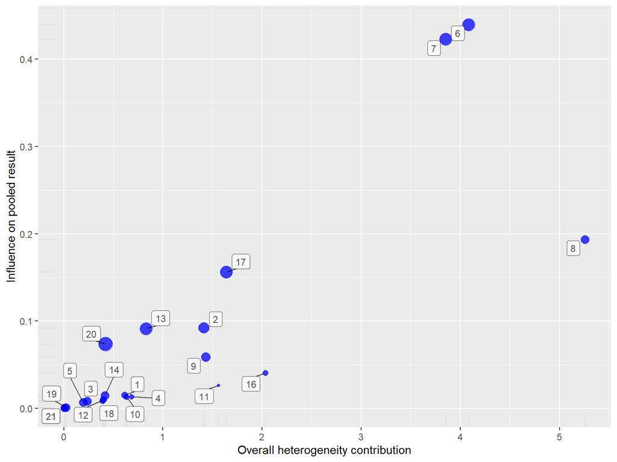

```r
plot(outl, "baujat", )
```

Forest plot

```r
outl <- InfluenceAnalysis(ma3, random = TRUE, text.scale = 1.5)
```

```
## [===========================================================================] DONE
```

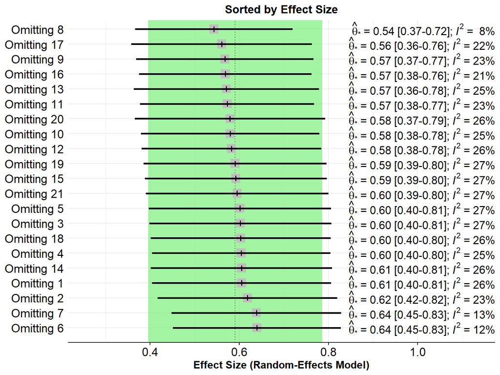

```r
plot(outl, "ES", text.scale = 2)
```

SMDs 6, 7, and 8 contribute disproportionately to both the variance and the pooled SMD.

### 1.2.3 Run meta-analysis without outliers

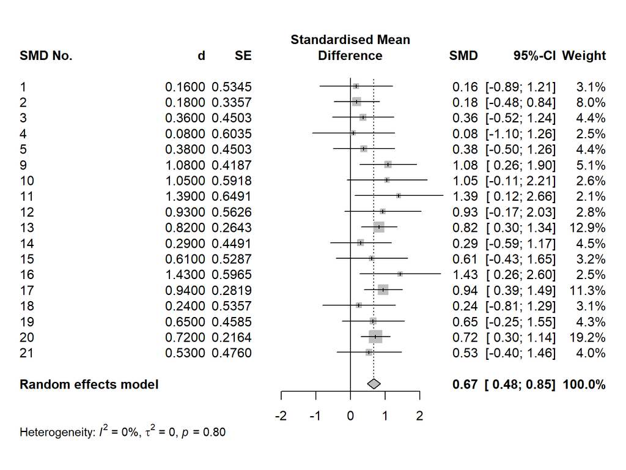

```r
s <- update(ma3, subset = -c(6, 7, 8))
forest(s,

            print.tau2 = TRUE,
            leftlabs = c("SMD No.", "d", "SE"))
```

Removing the outliers increases the pooled SMD by ~ 0.07 and eliminates between-study heterogeneity altogether.

# 2 Meta-analysis 2

```r
MA2 <- readRDS("data/preprocessed/MA_all.rds") %>%
  filter(id_ma == 2)
```

## 2.1 Publication bias analysis

### 2.1.1 PET-PEESE

Collate the necessary variables For the PET-PEESE model, the effect sizes (here SMDs), their SEs, their variances, and their inverse-variance weights, are needed.

```r
petpeese <- data.frame(smd = MA2$smd_ma) # smds
petpeese$v <- MA2$se_ma^2 # sampling variances (extracted from the figures)
petpeese$se <- MA2$se_ma # standard errors of SMD estimates
petpeese$w <- 1/petpeese$v # inverse variance weights
```

PET (precision-effect test)

```r
pet <- lm(smd ~ se, weights = w, data = petpeese)
summary(pet)$coefficients
```

```
##             Estimate Std. Error t value Pr(>|t|)
## (Intercept)    -0.12       0.31   -0.39     0.70
## se              1.77       0.84    2.10     0.05
```

PEESE (precision-effect estimate with standard error)

```r
peese <- lm(smd ~ v, weights = w, data = petpeese)
summary(peese)$coefficients
```

```
##             Estimate Std. Error t value Pr(>|t|)
## (Intercept)     0.21       0.18     1.2    0.255
```

### 2.1.2 P-Curve

P-Curve

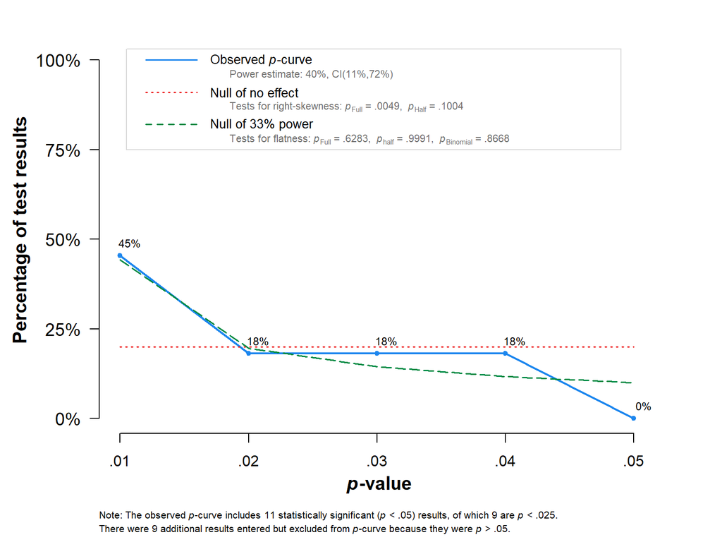

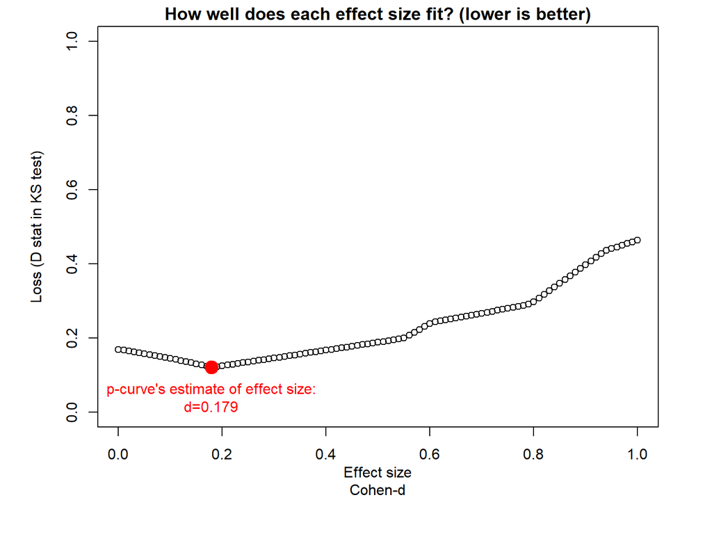

```
## P-curve analysis
##  -----------------------
## - Total number of provided studies: k = 20
## - Total number of p<0.05 studies included into the analysis: k = 11 (55%)
## - Total number of studies with p<0.025: k = 9 (45%)
##
## Results
##  -----------------------
##                     pBinomial zFull pFull zHalf pHalf
## Right-skewness test     0.033 -2.58 0.005  -1.3   0.1
## Flatness test           0.867  0.33 0.628   3.1   1.0
## Note: p-values of 0 or 1 correspond to p<0.001 and p>0.999, respectively.
## Power Estimate: 40% (11%-72%)
##
## Evidential value
##  -----------------------
## - Evidential value present: no
## - Evidential value absent/inadequate: no
##
## P-curve's estimate of the true effect size: d=0.18
##
## Warning: I-squared of the meta-analysis is >= 50%, so effect size estimates are not trustworthy.
```

```r
ma3 <- metagen(TE = smd_ma,
              seTE = se_ma,
              studlab = as.character(id_comparison),
              data = MA2,
              sm = "SMD",
              fixed = FALSE,
              random = TRUE, # a random effects MA.
              method.tau = "DL", # DerSimonian-Laird estimator
                 )


pcurve(ma3,
       effect.estimation = TRUE,
       N = MA2$nt_ma + MA2$nc_ma,
       dmin = 0,
       dmax = 1)
```

### 2.1.3 Three-parameter selection model

Create a `metafor` package meta-analysis object, necessary for the `selmodel` function

```r
ma3_metafor <- rma(yi = smd_ma,
          sei = se_ma,
          data = MA2,
          method = "DL")
```

Fit the selection model

```r
selmodel(ma3_metafor,
         type = "stepfun",
         steps = 0.025)
```

```
##
## Random-Effects Model (k = 20; tau^2 estimator: ML)
##
## tau^2 (estimated amount of total heterogeneity): 0.1405 (SE = 0.1169)
## tau (square root of estimated tau^2 value):      0.3748
##
## Test for Heterogeneity:
## LRT(df = 1) = 3.8793, p-val = 0.0489
##
## Model Results:
##
## estimate      se    zval    pval    ci.lb   ci.ub
##   0.1995  0.2025  0.9854  0.3244  -0.1973  0.5964
##
## Test for Selection Model Parameters:
## LRT(df = 1) = 4.9048, p-val = 0.0268
##
## Selection Model Results:
##
##                      k  estimate      se     zval    pval   ci.lb   ci.ub
## 0     < p <= 0.025  10    1.0000     ---      ---     ---     ---     ---
## 0.025 < p <= 1      10    0.1460  0.1326  -6.4416  <.0001  0.0000  0.4059  ***
##
## ---
## Signif. codes:  0 '***' 0.001 '**' 0.01 '*' 0.05 '.' 0.1 ' ' 1
```

## 2.2 Outlier/influence diagnostics

### 2.2.1 Leave-one-out analysis

```r
metainf(ma3, pooled = "random")
```

```
## Influential analysis (random effects model)
##
##                    SMD           95%-CI  p-value   tau^2     tau    I^2
## Omitting 1      0.5970 [0.2827; 0.9112]   0.0002  0.2756  0.5250  66.4%
## Omitting 2      0.5771 [0.2799; 0.8744]   0.0001  0.2465  0.4965  65.0%
## Omitting 3      0.6209 [0.2918; 0.9500]   0.0002  0.3104  0.5572  66.8%
## Omitting 4      0.5765 [0.2732; 0.8798]   0.0002  0.2547  0.5047  65.4%
## Omitting 5      0.6024 [0.2956; 0.9092]   0.0001  0.2709  0.5204  67.0%
## Omitting 6      0.6322 [0.3200; 0.9444] < 0.0001  0.2792  0.5284  67.4%
## Omitting 7      0.6403 [0.3291; 0.9516] < 0.0001  0.2764  0.5258  67.2%
## Omitting 8      0.6726 [0.3640; 0.9811] < 0.0001  0.2532  0.5032  62.8%
## Omitting 9      0.6714 [0.3608; 0.9820] < 0.0001  0.2588  0.5087  63.3%
## Omitting 10     0.5995 [0.2855; 0.9136]   0.0002  0.2765  0.5258  66.6%
## Omitting 11     0.5442 [0.2522; 0.8363]   0.0003  0.2205  0.4695  61.7%
## Omitting 12     0.6292 [0.3165; 0.9419] < 0.0001  0.2801  0.5292  67.5%
## Omitting 13     0.6508 [0.3167; 0.9850]   0.0001  0.3247  0.5698  67.2%
## Omitting 14     0.5575 [0.2633; 0.8517]   0.0002  0.2326  0.4823  63.4%
## Omitting 15     0.5931 [0.2844; 0.9019]   0.0002  0.2688  0.5184  66.5%
## Omitting 16     0.6431 [0.3305; 0.9556] < 0.0001  0.2776  0.5269  67.2%
## Omitting 17     0.6131 [0.3001; 0.9260]   0.0001  0.2792  0.5284  67.3%
## Omitting 18     0.6235 [0.3001; 0.9469]   0.0002  0.2975  0.5454  67.3%
## Omitting 19     0.6850 [0.4035; 0.9664] < 0.0001  0.1915  0.4376  57.9%
## Omitting 20     0.6002 [0.2837; 0.9167]   0.0002  0.2798  0.5290  66.4%
##
## Pooled estimate 0.6160 [0.3143; 0.9178] < 0.0001  0.2665  0.5163  65.7%
##
## Details on meta-analytical method:
## - Inverse variance method
## - DerSimonian-Laird estimator for tau^2
```

### 2.2.2 Some plots

Baujat

```r
outl <- InfluenceAnalysis(ma3, random = TRUE, text.scale = 2)
```

```
## [===========================================================================] DONE
```

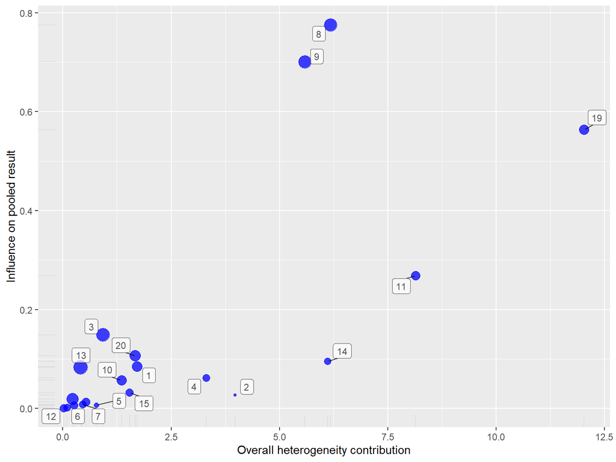

```r
plot(outl, "baujat")
```

Forest plot

```r
outl <- InfluenceAnalysis(ma3, random = TRUE, text.scale = 1.5)
```

```
## [===========================================================================] DONE
```

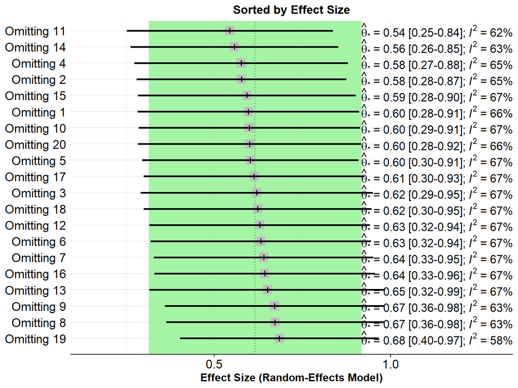

```r
plot(outl, "ES", text.scale = 2)
```

### 2.2.3 Run meta-analysis without outliers

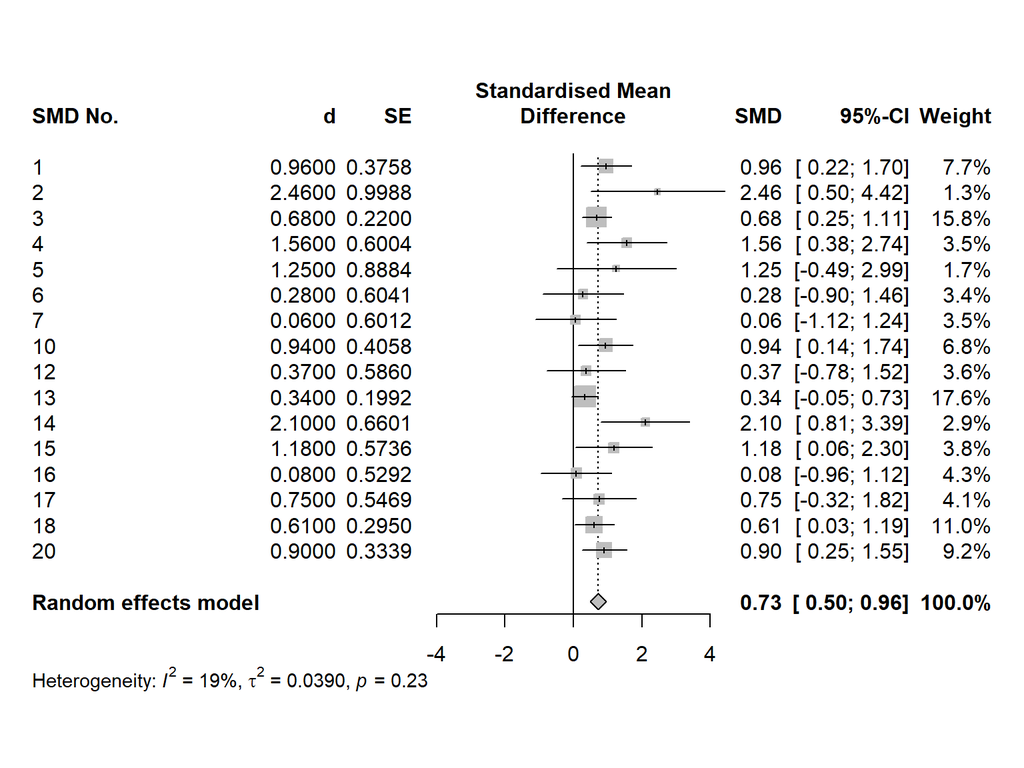

```r
s <- update(ma3, subset = -c(8, 9, 11, 19))
forest(s,

            print.tau2 = TRUE,
            leftlabs = c("SMD No.", "d", "SE"))
```

# 3 Meta-analysis 3

```r
MA3 <- readRDS("data/preprocessed/MA_all.rds") %>%
  filter(id_ma == 3)
```

## 3.1 Publication bias analysis

### 3.1.1 PET-PEESE

Collate the necessary variables For the PET-PEESE model, the effect sizes (here SMDs), their SEs, their variances, and their inverse-variance weights, are needed.

```r
petpeese <- data.frame(smd = MA3$smd_ma) # smds
petpeese$v <- MA3$v_ma # sampling variances (extracted from the figures)
petpeese$se <- MA3$se_ma # standard errors of SMD estimates
petpeese$w <- 1/petpeese$v # inverse variance weights
```

PET (precision-effect test)

```r
pet <- lm(smd ~ se, weights = w, data = petpeese)
summary(pet)$coefficients
```

```
##             Estimate Std. Error t value Pr(>|t|)
## (Intercept)    -0.71       0.58    -1.2    0.283
## se              4.04       1.67     2.4    0.073
```

PEESE (precision-effect estimate with standard error)

```r
peese <- lm(smd ~ v, weights = w, data = petpeese)
summary(peese)$coefficients
```

```
##             Estimate Std. Error t value Pr(>|t|)
## (Intercept)   0.0068       0.31   0.022    0.984
```

### 3.1.2 P-Curve

P-Curve

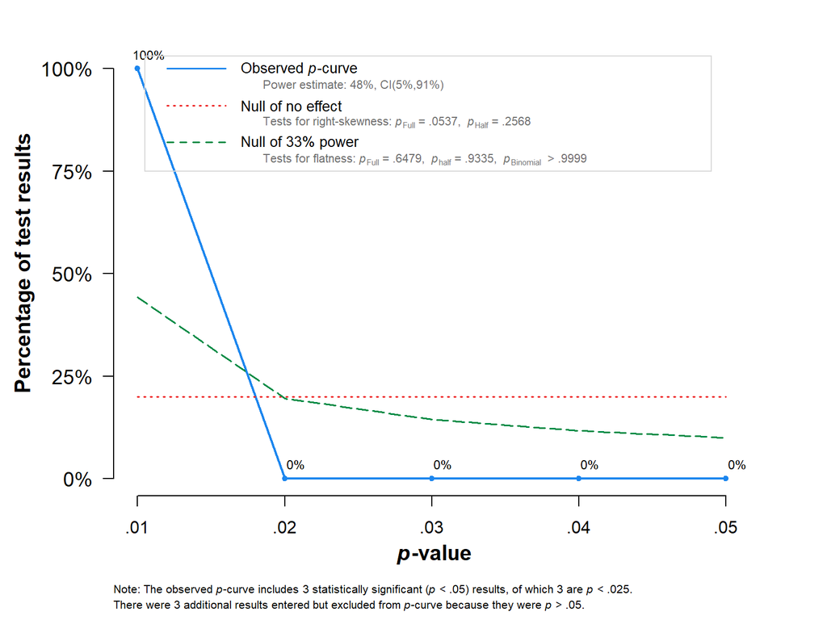

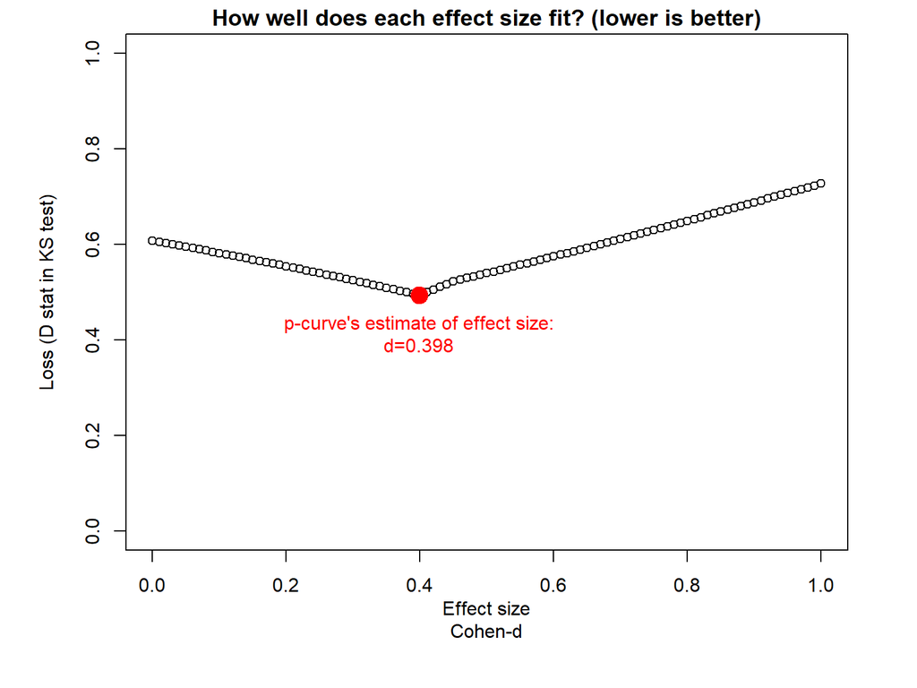

```
## P-curve analysis
##  -----------------------
## - Total number of provided studies: k = 6
## - Total number of p<0.05 studies included into the analysis: k = 3 (50%)
## - Total number of studies with p<0.025: k = 3 (50%)
##
## Results
##  -----------------------
##                     pBinomial zFull pFull zHalf pHalf
## Right-skewness test      0.12 -1.61 0.054 -0.65  0.26
## Flatness test            1.00  0.38 0.648  1.50  0.93
## Note: p-values of 0 or 1 correspond to p<0.001 and p>0.999, respectively.
## Power Estimate: 48% (5%-91%)
##
## Evidential value
##  -----------------------
## - Evidential value present: no
## - Evidential value absent/inadequate: no
##
## P-curve's estimate of the true effect size: d=0.4
```

```r
ma3 <- metagen(TE = smd_ma,
              seTE = se_ma,
              studlab = as.character(id_comparison),
              data = MA3,
              sm = "SMD",
              fixed = FALSE,
              random = TRUE, # a random effects MA.
              method.tau = "DL", # DerSimonian-Laird estimator
                 )

pcurve(ma3,
       effect.estimation = TRUE,
       N = MA3$nt_ma + MA3$nc_ma,
       dmin = 0,
       dmax = 1)
```

### 3.1.3 Three-parameter selection model

Create a `metafor` package meta-analysis object, necessary for the `selmodel` function

```r
ma3_metafor <- rma(yi = smd_ma,
          sei = se_ma,
          data = MA3,
          method = "DL")
```

Fit the selection model

```r
selmodel(ma3_metafor,
         type = "stepfun",
         steps = 0.025)
```

```
##
## Random-Effects Model (k = 6; tau^2 estimator: ML)
##
## tau^2 (estimated amount of total heterogeneity): 0.0000
## tau (square root of estimated tau^2 value):      0.0063
##
## Test for Heterogeneity:
## LRT(df = 1) = 0.0000, p-val = 1.0000
##
## Model Results:
##
## estimate      se    zval    pval   ci.lb   ci.ub
##   0.6187  0.2227  2.7784  0.0055  0.1822  1.0551  **
##
## Test for Selection Model Parameters:
## LRT(df = 1) = 0.0543, p-val = 0.8158
##
## Selection Model Results:
##
##                     k  estimate      se     zval    pval   ci.lb   ci.ub
## 0     < p <= 0.025  3    1.0000     ---      ---     ---     ---     ---
## 0.025 < p <= 1      3    0.7335  0.9746  -0.2734  0.7845  0.0000  2.6438
##
## ---
## Signif. codes:  0 '***' 0.001 '**' 0.01 '*' 0.05 '.' 0.1 ' ' 1
```

## 3.2 Outlier/influence diagnostics

### 3.2.1 Leave-one-out analysis

```r
metainf(ma3, pooled = "random")
```

```
## Influential analysis (random effects model)
##
##                    SMD           95%-CI  p-value   tau^2     tau    I^2
## Omitting 1      0.6279 [0.3035; 0.9523]   0.0001  0.0134  0.1158   9.6%
## Omitting 2      0.8089 [0.4865; 1.1313] < 0.0001  0.0000  0.0000   0.0%
## Omitting 3      0.6064 [0.3094; 0.9034] < 0.0001  0.0000  0.0000   0.0%
## Omitting 4      0.6004 [0.3101; 0.8906] < 0.0001  0.0000  0.0000   0.0%
## Omitting 5      0.6936 [0.3551; 1.0321] < 0.0001  0.0238  0.1544  15.8%
## Omitting 6      0.6845 [0.3620; 1.0071] < 0.0001  0.0222  0.1489  16.2%
##
## Pooled estimate 0.6587 [0.3831; 0.9342] < 0.0001  0.0000  0.0000   0.0%
##
## Details on meta-analytical method:
## - Inverse variance method
## - DerSimonian-Laird estimator for tau^2
```

### 3.2.2 Some plots

Baujat

```r
outl <- InfluenceAnalysis(ma3, random = TRUE, text.scale = 2)
```

```
## [===========================================================================] DONE
```

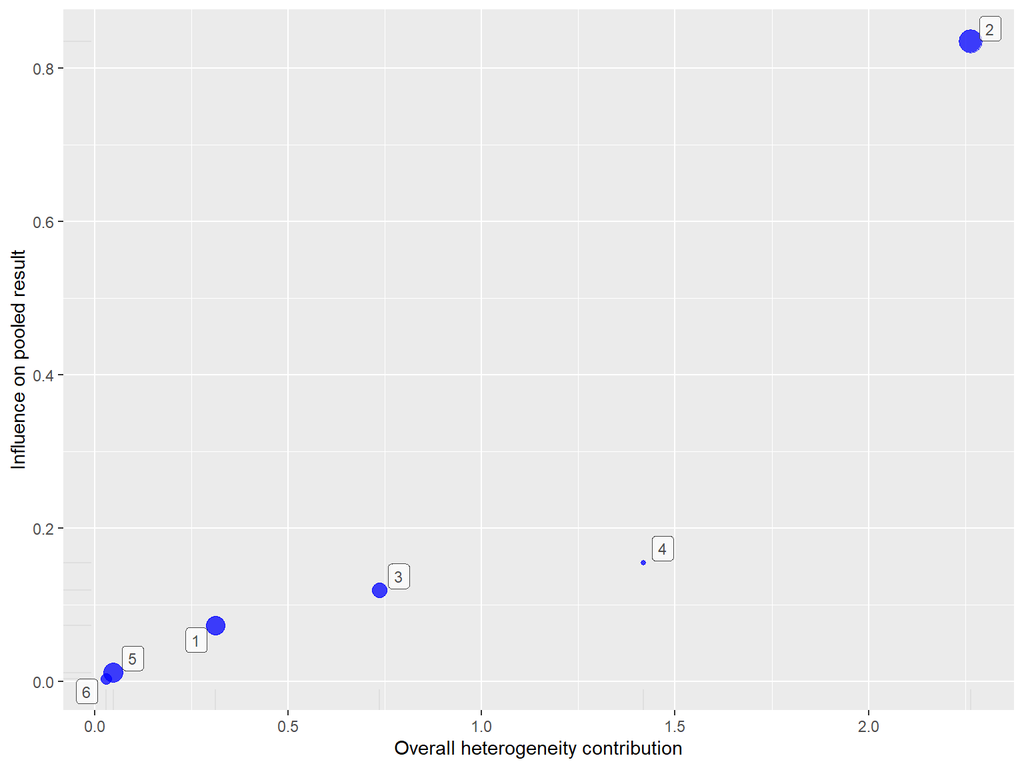

```r
plot(outl, "baujat")
```

Forest plot

```r
outl <- InfluenceAnalysis(ma3, random = TRUE, text.scale = 1.5)
```

```
## [===========================================================================] DONE
```

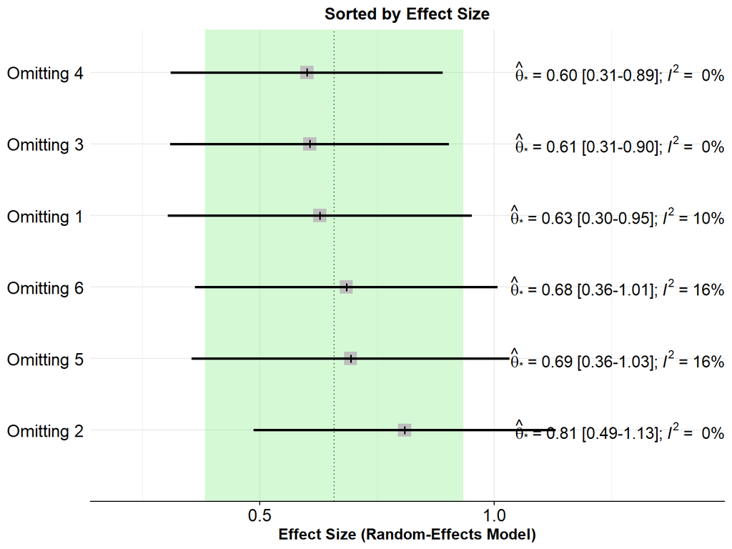

```r
plot(outl, "ES", text.scale = 2)
```

### 3.2.3 Run meta-analysis without outliers

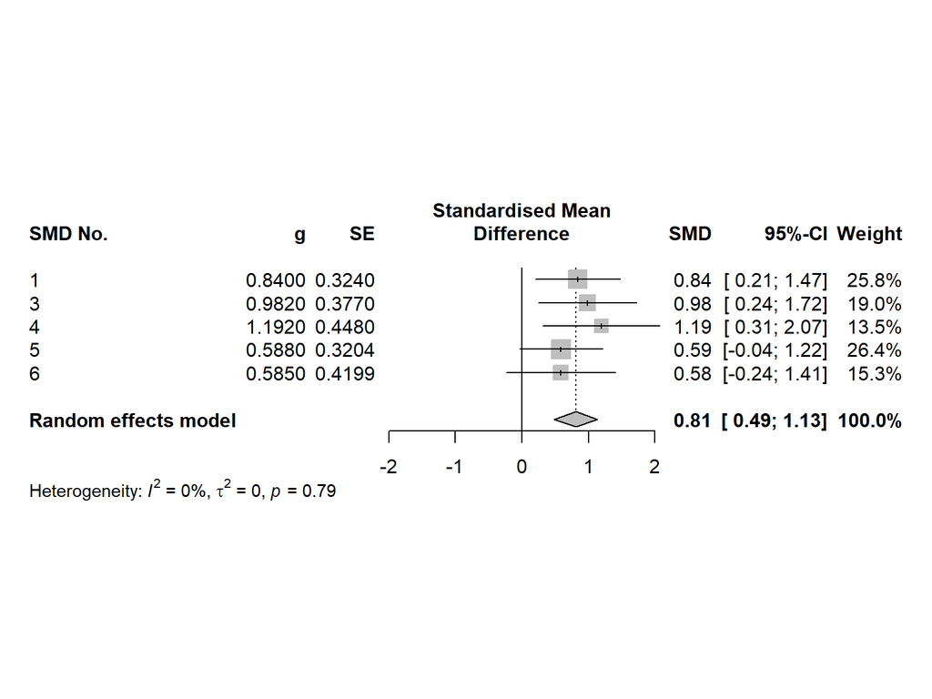

```r
s <- update(ma3, subset = -c(2))
forest(s,

            print.tau2 = TRUE,
            leftlabs = c("SMD No.", "g", "SE"))
```